# 5.2 Least Squares Linear Regression

In this Section we formally describe the problem of *linear regression*, or the fitting of a representative line (or hyperplane in higher dimensions) to a set of input/output data points.

Regression in general may be performed for a variety of reasons, in order to:

- produce a so-called trend line (or - more generally - a curve) that can be used to help visually summarize
- drive home a particular point about the data under study,
- or to learn a model so that precise predictions can be made regarding output values in the future.
- You can toggle the code on and off in this presentation via the button below.

```python
from IPython.display import HTML

HTML('''<script>
code_show=true;
function code_toggle() {
 if (code_show){
 $('div.input').hide();
 } else {
 $('div.input').show();
 }
 code_show = !code_show
}
$( document ).ready(code_toggle);
</script>
<form action="javascript:code_toggle()"><input type="submit" value="Click here to toggle on/off the raw code."></form>''')
```

## Notation and modeling

- Data for regression problems comes in the form of a set of $P$ input/output observation pairs

\begin{equation} \left(\mathbf{x}_{1},y_{1}\right),\,\left(\mathbf{x}_{2},y_{2}\right),\,...,\,\left(\mathbf{x}_{P},y_{P}\right) \end{equation}

- More compactly this is$\left\{ \left(\mathbf{x}_{p},y_{p}\right)\right\} _{p=1}^{P}$ , where $\mathbf{x}_{p}$ and $y_{p}$ denote the $p^{\textrm{th}}$ input and output respectively.
- In simple instances the input is scalar-valued (the output will always be considered scalar-valued here), and hence the linear regression problem is geometrically speaking one of fitting a line to the associated scatter of data points in 2-dimensional space.
- In general however each input $\mathbf{x}_{p}$ may be a column vector of length $N$

\begin{equation} \mathbf{x}_{p}=\begin{bmatrix} x_{1,p}\\ x_{2,p}\\ \vdots\\ x_{N,p} \end{bmatrix} \end{equation}

- In this case the linear regression problem is analogously one of fitting a hyperplane to a scatter of points in $N+1$ dimensional space.

[figure not shown]

- With scalar input we must determine appropriate vertical intercept $w_0$ and slope $w_1$ so that the following holds

\begin{equation} w_{0}+x_{p}w_{1}\approx y_{p},\quad p=1,...,P. \end{equation}

- Notice that we have used the approximately equal sign because we cannot be sure that all data lies completely on a single line.
- More generally, when dealing with $N$ dimensional input we have a bias and $N$ associated slope weights to tune properly

\begin{equation} w_{0}+ x_{1,p}w_{1} + x_{2,p}w_{2} + \cdots + x_{N,p}w_{N} \approx y_{p} ,\quad p=1,...,P. \end{equation}

- Note: each dimension of the *input* is referred to in the jargon of machine learning as a *feature* or *input feature*.
- So we will often refer to $w_{1,p},\,w_{2,p},\,...,w_{N,p}$ as the *feature-touching weights* (the only weight *not* touching a feature is the bias $w_0$).
- For any $N$ we can write the above more compactly - in particular using the notation $\mathring{\mathbf{x}}_{\,}$ to denote an input $\mathbf{x}_{\,}$ with a $1$ placed on top of it as

\begin{equation} \mathbf{w}=\begin{bmatrix} w_{0}\\ w_{1}\\ w_{2}\\ \vdots\\ w_{N} \end{bmatrix} \,\,\,\,\,\,\,\,\,\,\,\,\,\,\,\,\,\,\,\,\,\,\,\,\,\,\,\,\,\,\,\, \mathring{\mathbf{x}}_{\,}=\begin{bmatrix} 1 \\ x_{1}\\ x_{2}\\ \vdots\\ x_{N} \end{bmatrix}. \end{equation}

- In particular, this means that we stack a $1$ on top of each of our input points $\mathbf{x}_p$ as

\begin{equation} \mathring{\mathbf{x}}_p=\begin{bmatrix} 1 \\ x_{1,p}\\ x_{2,p}\\ \vdots\\ x_{N,p} \end{bmatrix},\,\,\,\, p = 1,...,P \end{equation}

- We may then write our desired linear relationships in equation (4) more compactly as

\begin{equation} \mathring{\mathbf{x}}_{p}^T\mathbf{w}^{\,} \approx \overset{\,}{y}_{p}^{\,} \quad p=1,...,P. \end{equation}

## The Least Squares cost function

- To find the parameters of the hyperplane which best fits a regression dataset, it is common practice to first form the *Least Squares cost function*.
- For a given set of parameters $\mathbf{w}$ this cost function computes the total squared error between the associated hyperplane and the data (as illustrated pictorially below).
- Naturally then the best fitting hyperplane is the one whose parameters minimize this error.

[figure not shown]

- Where does this "Least Squares" cost come from?
- Remember, we want to find a weight vector $\mathbf{w}$ so that each of $P$ approximate equalities below holds as tightly as possible

\begin{equation} \mathring{\mathbf{x}}_{p}^T\mathbf{w}^{\,} \approx y_{p} \end{equation}

- Another way of stating the above is to say that the *error* between $\mathring{\mathbf{x}}_{p}^T\mathbf{w}^{\,} $ and $y_{p}$ is small.
- One natural way to measure error between two quantities like this measure its *square* (so that both negative and positive errors are treating equally) as

\begin{equation} g_p\left(\mathbf{w}\right) = \left(\mathring{\mathbf{x}}_{p}^{T}\mathbf{w} - \overset{\,}{y}_p^{\,}\right)^2. \end{equation}

- This squared error $g_p\left(\cdot\right)$ is one example of a *point-wise cost* that measures the error of a model (here a linear one) on the point $\left\{\mathbf{x}_p,y_p\right\}$.
- Since we want all $P$ such values to be small we can take their average - forming a *Least Squares* cost function for linear regression

\begin{equation} \,g\left(\mathbf{w}\right)=\frac{1}{P}\sum_{p=1}^{P} g_p\left(\mathbf{w}\right) = \frac{1}{P}\sum_{p=1}^{P}\left(\mathring{\mathbf{x}}_{p}^{T}\mathbf{w}^{\,} - \overset{\,}{y}_p^{\,}\right)^{2} \end{equation}

- Note that the Least Squares cost function is not just a function of the weights $\mathbf{w}$, but of the data as well.
- However when we express the function in mathematical shorthand as $g\left(\mathbf{w}\right)$ (as we do on the lefthand side above) we only show dependency on the weights $\mathbf{w}$.
- Why do we do this? Largely for notational simplicity: if we show dependency in our functional shorthand and write $g\left(\mathbf{w} ; \left\{\mathring{\mathbf{x}}_{p},\,y_p\right\}_{p=1}^{P} \right)$ things start to get too messy.
- Moreover, for a given dataset the weights $\mathbf{w}$ are the important input - since this is what we need to tune in order to produce a good fit.
- Because of this we will often refer to the Least Squares cost using the notation $g\left(\mathbf{w}\right)$, but the reader can keep in mind this subtle point that it is indeed a function of the data as well.
- We will make this sort of notational simplification for virtually all future machine learning cost functions we study as well.
- Indeed we want to tune our parmeters $\mathbf{w}$ to *minimize* the Least Squares cost...
- ...since the larger this value becomes the larger the squared error between the corresponding linear model and the data, and hence the poorer we represent the given dataset using a linear model.
- In other words, we want to determine a value for weights $\mathbf{w}$ that *minimizes* $g\left(\mathbf{w}\right)$, or written formally

\begin{equation} \underset{\mathbf{w}}{\mbox{minimize}}\,\,\frac{1}{P}\underset{p=1}{\overset{P}{\sum}}\left(\mathring{\mathbf{x}}_{p}^{T}\mathbf{w}^{\,}-\overset{\,}{y}_p^{\,}\right)^{2} \end{equation}

## Implementing the Least Squares cost in `Python`

- When implementing a cost function like Least squares it is helpful to think modularly, with the aim lightening the amount of mental 'bookkeeping' required, breaking down the cost into a few distinct pieces.
- Here we can really break things down into two chunks: we have our *model* - a linear combination of input - and the cost (squared error) itself.
- We can express our linear model - a function of our input and weights - is a function worthy enough of its own notation.
- We will write it as

\begin{equation} \text{model}\left(\mathbf{x}_{p},\mathbf{w}\right) = \mathring{\mathbf{x}}_{p}^T \mathbf{w}. \end{equation}

- If we were to go back then and use this modeling notation we could equally well e.g., our ideal settings of the weights our original approximation as

\begin{equation} \text{model}\left(\mathbf{x}_{p},\mathbf{w}\right) \approx y_p \end{equation}

- and likewise our Least Squares cost function itself as

\begin{equation} \,g\left(\mathbf{w}\right)=\frac{1}{P}\sum_{p=1}^{P}\left(\text{model}\left(\mathbf{x}_{p},\mathbf{w}\right) -y_{p}^{\,}\right)^{2}. \end{equation}

- To write this in `Python` we un-ravel the bias from our weights, using slicing and express the model computation as follows

  ```
                        a = w[0] + np.dot(x_p.T,w[1:])
  ```

- The linear combination $\mathbf{x}_p^T \mathbf{w}_{[1:]}^{\,}$ - implemented using `np.dot` - is very efficient (far more than an explicit for loop in `Python`).

```python
# compute linear combination of input point
def model(x_p,w):
    # compute linear combination and return
    a = w[0] + np.dot(x_p.T,w[1:])
    return a.T
```

- Next, in writing out the Least Squares function we could explicitly loop over our $P$ points one at-a-time.

```python
# a least squares function for linear regression
def least_squares(w,x,y):
    # loop over points and compute cost contribution from each input/output pair
    cost = 0
    for p in range(y.size):
        # get pth input/output pair
        x_p = x[:,p][:,np.newaxis]
        y_p = y[p]

        ## add to current cost
        cost += (model(x_p,w)  - y_p)**2

    # return average least squares error
    return cost/float(y.size)
```

- However when such for loops can be equivalently written using `numpy` operations, this is typically far more efficient.
- *Explicit* `for` loops (including list comprehensions) written in `Python` are rather slow due to the very nature of the language (e.g., it being a [dynamically typed interpreted language](https://jakevdp.github.io/blog/2014/05/09/why-python-is-slow/)).
- It is easy to get around most of this inefficiency by replacing explicit `for` loops with numerically equivalent operations performed using operations from the [`numpy` library](http://www.numpy.org/).
- `numpy` is an API for some very efficient vector/matrix manipulation libraries written in `C`. In fact `Python` code, employing heavy use of `numpy` functions, can often execute almost as fast a raw `C` implementation itself.
- Below we show compact implementations of both our model and Least Squares cost in `Python` leveraging `numpy`.

```python
# compute linear combination of input points
def model(x,w):
    a = w[0] + np.dot(x.T,w[1:])
    return a.T

# an implementation of the least squares cost function for linear regression
def least_squares(w):
    # compute the least squares cost
    cost = np.sum((model(x,w) - y)**2)
    return cost/float(y.size)
```

- Notice too that for simplicity we write the the `Pythonic` Least Squares cost function `least_squares(w)` instead of `least_squares(w,x,y)`, where in the latter case we explicitly list its other two arguments: the input `x` and output `y` data.
- This is done for notational simplicity, as `autograd` will correctly differentiate both forms (since by default it computes the gradient of a `Python` function with respect to its first input only).
- We will use this kind of simplified `Pythonic` notation when introducing future machine learning cost functions as well.

## Minimization of the Least Squares cost function

- Now, determining the overall shape of a function - i.e., whether or not a function is convex - helps determine the appropriate optimization method(s) we can apply to efficiently determine the ideal parameters.
- In the case of the Least Squares cost function for linear regression it is easy to check that *the cost function is always convex regardless of the dataset*.
- Indeed further, it is always a *convex quadratic function* for any dataset used.
- For small input dimensions (e.g., $N=1$) we can empirically verify this claim for any given dataset by simply plotting the function $g$ - as a surface and/or contour plot - as we do in the example below.

#### Example. Visually verifying the convexity of the cost function for a toy dataset

- In this example we plot the contour and surface plot for the Least Squares cost function for linear regression for a toy dataset.
- This toy dataset consists of 50 points randomly selected off of the line $y = x$, with a small amount of Gaussian noise added to each.
- Notice that the data is packaged in a $\left(N+1\right)\times P$ array, with the input being in the top $N$ rows and the corresponding output is the last row.

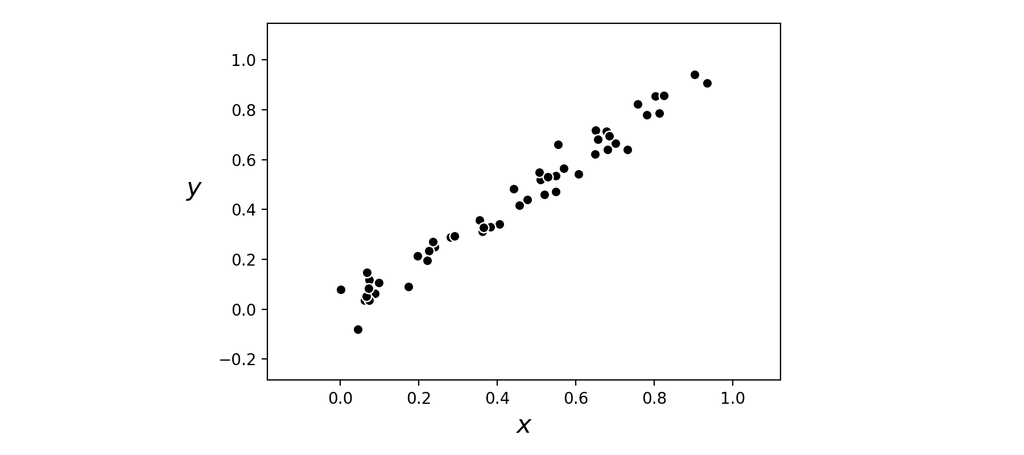

```python
# This code cell will not be shown in the HTML version of this notebook
# load in dataset
data = np.loadtxt(datapath + '2d_linregress_data.csv',delimiter = ',')
x = data[:-1,:]
y = data[-1:,:]

# plot dataset
demo = regress_plotter.Visualizer(data)
demo.plot_data()
```

- The contour plot and corresponding surface generated by the Least Squares cost function using this data are shown below.

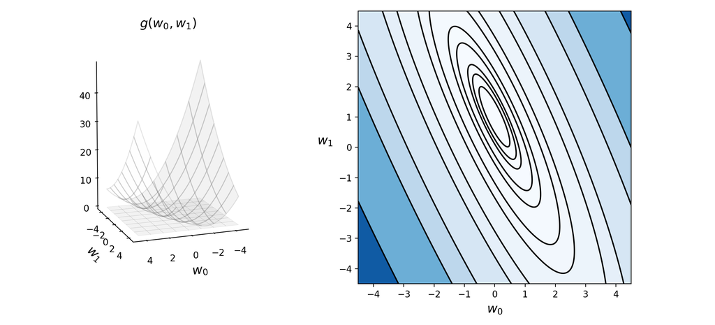

```python
## This code cell will not be shown in the HTML version of this notebook
# show run in both three-dimensions and just the input space via the contour plot
static_plotter.two_input_surface_contour_plot(least_squares,[],view = [10,70],xmin = -4.5, xmax = 4.5, ymin = -4.5, ymax = 4.5,num_contours = 30)
```

#### Example. Using gradient descent to minimize the Least Squares cost on our toy dataset

```python
## This code cell will not be shown in the HTML version of this notebook
# load video into notebook
from IPython.display import HTML
HTML("""
<video width="1000" height="400" controls loop>
  <source src="videos/animation_1.mp4" type="video/mp4">
  </video>
""")
```

[video not shown]

- Whenever we use a local optimization method like gradient descent we must properly tune the steplength parameter $\alpha$.
- We did this for the run above by trying several fixed steplength values.
- Below we re-create those runs using $\alpha = 0.5$, $\alpha = 0.01$, showing the the cost function history plot for each steplength value choice. We can see from the plot that indeed the first steplength value works considerably better.

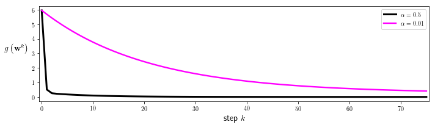

```python
## This code cell will not be shown in the HTML version of this notebook
# run gradient descent to minimize the Least Squares cost for linear regression
g = least_squares; w = np.array([-1.0,-2.0])[:,np.newaxis]; max_its = 75; alpha_choice = 0.5;
weight_history_1,cost_history_1 = optimizers.gradient_descent(g,alpha_choice,max_its,w)

# run gradient descent to minimize the Least Squares cost for linear regression
g = least_squares; w = np.array([-1.0,-2.0])[:,np.newaxis]; max_its = 75; alpha_choice = 10**(-2);
weight_history_2,cost_history_2 = optimizers.gradient_descent(g,alpha_choice,max_its,w)

# plot the cost function history for a given run
static_plotter.plot_cost_histories([cost_history_1,cost_history_2],start = 0,points = False,labels = [r'$\alpha = 0.5$',r'$\alpha = 0.01$'])
```

#### Example. Completely minimizing the Least Squares cost function using a single Newton step

```python
## This code cell will not be shown in the HTML version of this notebook
# load video into notebook
from IPython.display import HTML
HTML("""
<video width="1000" height="400" controls loop>
  <source src="videos/animation_3.mp4" type="video/mp4">
  </video>
""")
```

[video not shown]